# t3

## Spotify Behavior FFNN (Clean)

by Kyle Furey & Dhruv Solanki

This notebook trains a feed-forward neural network to predict **skipped_synth** (behavioral skip label) from Spotify-derived features in `../data/spotify_final_with_behavior.csv`.

```python
# Imports
%matplotlib inline
import numpy as np
import pandas as pd
import matplotlib.pyplot as plt
from sklearn.model_selection import train_test_split
from sklearn.preprocessing import StandardScaler
from sklearn.metrics import classification_report, roc_auc_score, confusion_matrix, ConfusionMatrixDisplay
from tensorflow import keras as tfk
from tensorflow.keras import layers as tfl
from tensorflow.keras import callbacks as tfkc
```

```python
# Load behavioral Spotify dataset
DATA_PATH = '../data/spotify_final_with_behavior.csv'

print('Loading data from', DATA_PATH)
df = pd.read_csv(DATA_PATH)
print('Shape:', df.shape)
print('Columns:', df.columns.tolist())

# Define features and target
numeric_features = ['spotify_popularity', 'is_explicit', 'album_release_year', 'tempo_bpm_synth']
cat_feature = 'time_of_day_synth'
target_column = 'skipped_synth'

X_num = df[numeric_features].copy()
X_cat = df[[cat_feature]].copy()
y = df[target_column].astype(int).values

# One-hot encode time_of_day_synth
X_cat_dummies = pd.get_dummies(X_cat, columns=[cat_feature], drop_first=False)
X = pd.concat([X_num, X_cat_dummies], axis=1)
feature_names = X.columns.tolist()
print('Final feature columns:', feature_names)

# Scale numeric features on the full dataset
scaler = StandardScaler()
X_num_scaled = scaler.fit_transform(X[numeric_features])
X.loc[:, numeric_features] = X_num_scaled

# Use the full dataset for training and evaluation
X_train_np = X.values.astype('float32')
X_test_np = X_train_np  # same as train
y_train = y
y_test = y

print('Using full dataset for training and evaluation:', X_train_np.shape[0], 'rows')
```

```
Loading data from ../data/spotify_final_with_behavior.csv
Shape: (40000, 15)
Columns: ['song_spotify_id', 'song_name', 'artist_name', 'genre', 'tags', 'spotify_popularity', 'is_explicit', 'album_name', 'album_release_date', 'album_release_year', 'position', 'artist_ids', 'tempo_bpm_synth', 'time_of_day_synth', 'skipped_synth']
Final feature columns: ['spotify_popularity', 'is_explicit', 'album_release_year', 'tempo_bpm_synth', 'time_of_day_synth_afternoon', 'time_of_day_synth_evening', 'time_of_day_synth_morning', 'time_of_day_synth_night']
Using full dataset for training and evaluation: 40000 rows
```

```python
# Build and train FFNN for behavioral skip prediction

input_dim = X_train_np.shape[1]
print('Input dimension:', input_dim)

model = tfk.Sequential([
    tfl.Input(shape=(input_dim,)),
    tfl.Dense(32, activation='relu'),
    tfl.Dropout(0.3),
    tfl.Dense(16, activation='relu'),
    tfl.Dense(1, activation='sigmoid'),
])

model.compile(
    optimizer=tfk.optimizers.Adam(learning_rate=1e-3),
    loss=tfk.losses.BinaryCrossentropy(),
    metrics=[tfk.metrics.BinaryAccuracy(name='accuracy')]
)

model.summary()

# Early stopping on validation loss (using validation_split)
callbacks = [
    tfkc.EarlyStopping(monitor='val_loss', patience=10, restore_best_weights=True)
]

history = model.fit(
    X_train_np, y_train,
    validation_split=0.1,
    epochs=100,
    batch_size=256,
    verbose=1,
    callbacks=callbacks
)
```

```
Input dimension: 8
```

```
Model: "sequential"
```

```
┏━━━━━━━━━━━━━━━━━━━━━━━━━━━━━━━━━┳━━━━━━━━━━━━━━━━━━━━━━━━┳━━━━━━━━━━━━━━━┓
┃ Layer (type)                    ┃ Output Shape           ┃       Param # ┃
┡━━━━━━━━━━━━━━━━━━━━━━━━━━━━━━━━━╇━━━━━━━━━━━━━━━━━━━━━━━━╇━━━━━━━━━━━━━━━┩
│ dense (Dense)                   │ (None, 32)             │           288 │
├─────────────────────────────────┼────────────────────────┼───────────────┤
│ dropout (Dropout)               │ (None, 32)             │             0 │
├─────────────────────────────────┼────────────────────────┼───────────────┤
│ dense_1 (Dense)                 │ (None, 16)             │           528 │
├─────────────────────────────────┼────────────────────────┼───────────────┤
│ dense_2 (Dense)                 │ (None, 1)              │            17 │
└─────────────────────────────────┴────────────────────────┴───────────────┘
```

```
 Total params: 833 (3.25 KB)
```

```
 Trainable params: 833 (3.25 KB)
```

```
 Non-trainable params: 0 (0.00 B)
```

```
141/141 ━━━━━━━━━━━━━━━━━━━━ 1s 1ms/step - accuracy: 0.8296 - loss: 0.4446 - val_accuracy: 0.9055 - val_loss: 0.3199
141/141 ━━━━━━━━━━━━━━━━━━━━ 0s 560us/step - accuracy: 0.9032 - loss: 0.3325 - val_accuracy: 0.9055 - val_loss: 0.3163
141/141 ━━━━━━━━━━━━━━━━━━━━ 0s 548us/step - accuracy: 0.9032 - loss: 0.3298 - val_accuracy: 0.9055 - val_loss: 0.3159
141/141 ━━━━━━━━━━━━━━━━━━━━ 0s 596us/step - accuracy: 0.9032 - loss: 0.3280 - val_accuracy: 0.9055 - val_loss: 0.3146
141/141 ━━━━━━━━━━━━━━━━━━━━ 0s 624us/step - accuracy: 0.9032 - loss: 0.3258 - val_accuracy: 0.9055 - val_loss: 0.3147
141/141 ━━━━━━━━━━━━━━━━━━━━ 0s 612us/step - accuracy: 0.9032 - loss: 0.3231 - val_accuracy: 0.9055 - val_loss: 0.3143
141/141 ━━━━━━━━━━━━━━━━━━━━ 0s 596us/step - accuracy: 0.9032 - loss: 0.3230 - val_accuracy: 0.9055 - val_loss: 0.3141
141/141 ━━━━━━━━━━━━━━━━━━━━ 0s 609us/step - accuracy: 0.9032 - loss: 0.3224 - val_accuracy: 0.9055 - val_loss: 0.3144
141/141 ━━━━━━━━━━━━━━━━━━━━ 0s 581us/step - accuracy: 0.9032 - loss: 0.3217 - val_accuracy: 0.9055 - val_loss: 0.3137
141/141 ━━━━━━━━━━━━━━━━━━━━ 0s 618us/step - accuracy: 0.9032 - loss: 0.3207 - val_accuracy: 0.9055 - val_loss: 0.3146
141/141 ━━━━━━━━━━━━━━━━━━━━ 0s 613us/step - accuracy: 0.9032 - loss: 0.3211 - val_accuracy: 0.9055 - val_loss: 0.3137
141/141 ━━━━━━━━━━━━━━━━━━━━ 0s 614us/step - accuracy: 0.9032 - loss: 0.3207 - val_accuracy: 0.9055 - val_loss: 0.3136
141/141 ━━━━━━━━━━━━━━━━━━━━ 0s 625us/step - accuracy: 0.9032 - loss: 0.3201 - val_accuracy: 0.9055 - val_loss: 0.3142
141/141 ━━━━━━━━━━━━━━━━━━━━ 0s 543us/step - accuracy: 0.9032 - loss: 0.3196 - val_accuracy: 0.9055 - val_loss: 0.3136
141/141 ━━━━━━━━━━━━━━━━━━━━ 0s 598us/step - accuracy: 0.9032 - loss: 0.3192 - val_accuracy: 0.9055 - val_loss: 0.3144
141/141 ━━━━━━━━━━━━━━━━━━━━ 0s 599us/step - accuracy: 0.9032 - loss: 0.3189 - val_accuracy: 0.9055 - val_loss: 0.3135
141/141 ━━━━━━━━━━━━━━━━━━━━ 0s 597us/step - accuracy: 0.9032 - loss: 0.3190 - val_accuracy: 0.9055 - val_loss: 0.3140
141/141 ━━━━━━━━━━━━━━━━━━━━ 0s 597us/step - accuracy: 0.9032 - loss: 0.3189 - val_accuracy: 0.9055 - val_loss: 0.3136
141/141 ━━━━━━━━━━━━━━━━━━━━ 0s 617us/step - accuracy: 0.9032 - loss: 0.3182 - val_accuracy: 0.9055 - val_loss: 0.3139
141/141 ━━━━━━━━━━━━━━━━━━━━ 0s 608us/step - accuracy: 0.9032 - loss: 0.3180 - val_accuracy: 0.9055 - val_loss: 0.3133
141/141 ━━━━━━━━━━━━━━━━━━━━ 0s 625us/step - accuracy: 0.9032 - loss: 0.3186 - val_accuracy: 0.9055 - val_loss: 0.3134
141/141 ━━━━━━━━━━━━━━━━━━━━ 0s 567us/step - accuracy: 0.9032 - loss: 0.3185 - val_accuracy: 0.9055 - val_loss: 0.3134
141/141 ━━━━━━━━━━━━━━━━━━━━ 0s 598us/step - accuracy: 0.9032 - loss: 0.3183 - val_accuracy: 0.9055 - val_loss: 0.3133
141/141 ━━━━━━━━━━━━━━━━━━━━ 0s 571us/step - accuracy: 0.9032 - loss: 0.3182 - val_accuracy: 0.9055 - val_loss: 0.3136
141/141 ━━━━━━━━━━━━━━━━━━━━ 0s 586us/step - accuracy: 0.9032 - loss: 0.3184 - val_accuracy: 0.9055 - val_loss: 0.3134
141/141 ━━━━━━━━━━━━━━━━━━━━ 0s 633us/step - accuracy: 0.9032 - loss: 0.3178 - val_accuracy: 0.9055 - val_loss: 0.3134
141/141 ━━━━━━━━━━━━━━━━━━━━ 0s 627us/step - accuracy: 0.9032 - loss: 0.3181 - val_accuracy: 0.9055 - val_loss: 0.3133
141/141 ━━━━━━━━━━━━━━━━━━━━ 0s 610us/step - accuracy: 0.9032 - loss: 0.3180 - val_accuracy: 0.9055 - val_loss: 0.3134
141/141 ━━━━━━━━━━━━━━━━━━━━ 0s 583us/step - accuracy: 0.9032 - loss: 0.3180 - val_accuracy: 0.9055 - val_loss: 0.3133
141/141 ━━━━━━━━━━━━━━━━━━━━ 0s 602us/step - accuracy: 0.9032 - loss: 0.3178 - val_accuracy: 0.9055 - val_loss: 0.3137
141/141 ━━━━━━━━━━━━━━━━━━━━ 0s 580us/step - accuracy: 0.9032 - loss: 0.3179 - val_accuracy: 0.9055 - val_loss: 0.3133
141/141 ━━━━━━━━━━━━━━━━━━━━ 0s 581us/step - accuracy: 0.9032 - loss: 0.3178 - val_accuracy: 0.9055 - val_loss: 0.3136
141/141 ━━━━━━━━━━━━━━━━━━━━ 0s 543us/step - accuracy: 0.9032 - loss: 0.3179 - val_accuracy: 0.9055 - val_loss: 0.3133
141/141 ━━━━━━━━━━━━━━━━━━━━ 0s 543us/step - accuracy: 0.9032 - loss: 0.3178 - val_accuracy: 0.9055 - val_loss: 0.3136
141/141 ━━━━━━━━━━━━━━━━━━━━ 0s 599us/step - accuracy: 0.9032 - loss: 0.3178 - val_accuracy: 0.9055 - val_loss: 0.3134
141/141 ━━━━━━━━━━━━━━━━━━━━ 0s 623us/step - accuracy: 0.9032 - loss: 0.3178 - val_accuracy: 0.9055 - val_loss: 0.3138
141/141 ━━━━━━━━━━━━━━━━━━━━ 0s 571us/step - accuracy: 0.9032 - loss: 0.3179 - val_accuracy: 0.9055 - val_loss: 0.3134
141/141 ━━━━━━━━━━━━━━━━━━━━ 0s 502us/step - accuracy: 0.9032 - loss: 0.3177 - val_accuracy: 0.9055 - val_loss: 0.3135
141/141 ━━━━━━━━━━━━━━━━━━━━ 0s 531us/step - accuracy: 0.9032 - loss: 0.3177 - val_accuracy: 0.9055 - val_loss: 0.3136
141/141 ━━━━━━━━━━━━━━━━━━━━ 0s 526us/step - accuracy: 0.9032 - loss: 0.3176 - val_accuracy: 0.9055 - val_loss: 0.3136
141/141 ━━━━━━━━━━━━━━━━━━━━ 0s 600us/step - accuracy: 0.9032 - loss: 0.3179 - val_accuracy: 0.9055 - val_loss: 0.3135
```

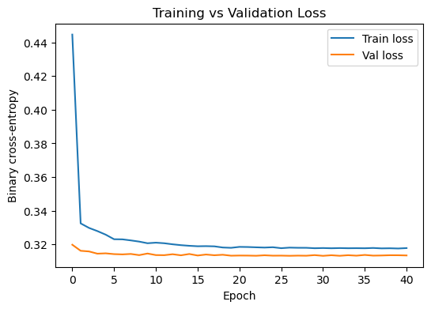

```python
# Plot training & validation loss
plt.figure(figsize=(6,4))
plt.plot(history.history['loss'], label='Train loss')
plt.plot(history.history['val_loss'], label='Val loss')
plt.xlabel('Epoch')
plt.ylabel('Binary cross-entropy')
plt.title('Training vs Validation Loss')
plt.legend()
plt.show()
```

```
Evaluating on test set ...
1250/1250 ━━━━━━━━━━━━━━━━━━━━ 0s 211us/step

Classification report (0 = not skipped, 1 = skipped):
              precision    recall  f1-score   support

           0      0.903     1.000     0.949     36139
           1      0.000     0.000     0.000      3861

    accuracy                          0.903     40000
   macro avg      0.452     0.500     0.475     40000
weighted avg      0.816     0.903     0.858     40000

ROC AUC: 0.527
```

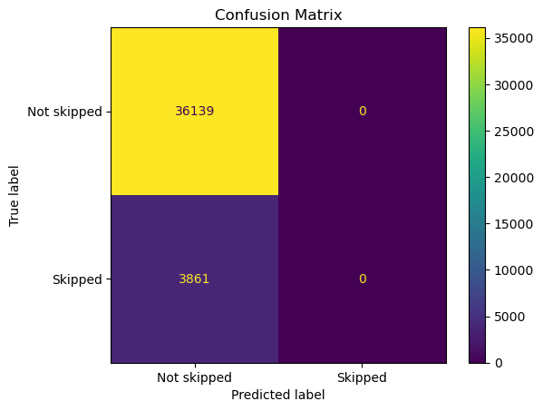

```python
# Evaluate on test set
print('Evaluating on test set ...')

probs = model.predict(X_test_np).ravel()
preds = (probs >= 0.5).astype(int)

print('\nClassification report (0 = not skipped, 1 = skipped):')
print(classification_report(y_test, preds, digits=3))

try:
    auc = roc_auc_score(y_test, probs)
    print(f'ROC AUC: {auc:.3f}')
except Exception as e:
    print('Could not compute ROC AUC:', e)

cm = confusion_matrix(y_test, preds)
ConfusionMatrixDisplay(cm, display_labels=['Not skipped', 'Skipped']).plot()
plt.title('Confusion Matrix')
plt.show()
```

```python
# Optional: simple Random Forest baseline for comparison
from sklearn.ensemble import RandomForestClassifier

rf = RandomForestClassifier(
    n_estimators=300,
    max_depth=None,
    min_samples_leaf=2,
    random_state=42,
    n_jobs=-1,
    class_weight='balanced_subsample',
)

print('Training RandomForest baseline ...')
rf.fit(X_train_np, y_train)
rf_probs = rf.predict_proba(X_test_np)[:, 1]
rf_preds = (rf_probs >= 0.5).astype(int)

print('\nRandomForest classification report:')
print(classification_report(y_test, rf_preds, digits=3))
print('RandomForest ROC AUC:', roc_auc_score(y_test, rf_probs))
```

```
Training RandomForest baseline ...

RandomForest classification report:
              precision    recall  f1-score   support

           0      1.000     0.997     0.998     36139
           1      0.972     0.999     0.985      3861

    accuracy                          0.997     40000
   macro avg      0.986     0.998     0.992     40000
weighted avg      0.997     0.997     0.997     40000

RandomForest ROC AUC: 0.9994810212165424
```

## PyTorch FFNN on Behavioral Dataset

This section mirrors the project description: we implement a feedforward neural network in **PyTorch** to predict `skipped_synth` from the behavioral Spotify dataset (`../data/spotify_final_with_behavior.csv`).

```python
# PyTorch imports
import torch
from torch import nn
from torch.utils.data import Dataset, DataLoader

print('PyTorch version:', torch.__version__)
```

```
PyTorch version: 2.9.1
```

```python
# Reuse the preprocessed features from earlier cells
# We build train/val/test splits specifically for the PyTorch model.

from sklearn.model_selection import train_test_split

X_all = X.values.astype('float32')  # from earlier preprocessing cell
y_all = y.astype('float32')         # from earlier preprocessing cell

X_train_pt, X_temp_pt, y_train_pt, y_temp_pt = train_test_split(
    X_all, y_all, test_size=0.3, random_state=42, stratify=y_all
)
X_val_pt, X_test_pt, y_val_pt, y_test_pt = train_test_split(
    X_temp_pt, y_temp_pt, test_size=0.5, random_state=42, stratify=y_temp_pt
)

print('PyTorch splits:')
print('  Train:', X_train_pt.shape[0])
print('  Val  :', X_val_pt.shape[0])
print('  Test :', X_test_pt.shape[0])
```

```
PyTorch splits:
  Train: 28000
  Val  : 6000
  Test : 6000
```

```python
class BehaviorDataset(Dataset):
    def __init__(self, X, y):
        self.X = torch.tensor(X, dtype=torch.float32)
        self.y = torch.tensor(y, dtype=torch.float32).view(-1, 1)

    def __len__(self):
        return self.X.shape[0]

    def __getitem__(self, idx):
        return self.X[idx], self.y[idx]

batch_size = 256

train_dataset = BehaviorDataset(X_train_pt, y_train_pt)
val_dataset   = BehaviorDataset(X_val_pt, y_val_pt)
test_dataset  = BehaviorDataset(X_test_pt, y_test_pt)

train_loader = DataLoader(train_dataset, batch_size=batch_size, shuffle=True)
val_loader   = DataLoader(val_dataset, batch_size=batch_size)
test_loader  = DataLoader(test_dataset, batch_size=batch_size)

len(train_dataset), len(val_dataset), len(test_dataset)
```

```
(28000, 6000, 6000)
```

```python
# Define FFNN in PyTorch

input_dim = X_all.shape[1]
print('PyTorch model input_dim =', input_dim)

class FFNN(nn.Module):
    def __init__(self, input_dim):
        super().__init__()
        self.net = nn.Sequential(
            nn.Linear(input_dim, 32),
            nn.ReLU(),
            nn.Dropout(0.3),
            nn.Linear(32, 16),
            nn.ReLU(),
            nn.Linear(16, 1),
            nn.Sigmoid(),
        )

    def forward(self, x):
        return self.net(x)

model_pt = FFNN(input_dim)
criterion = nn.BCELoss()
optimizer = torch.optim.Adam(model_pt.parameters(), lr=1e-3)

model_pt
```

```
PyTorch model input_dim = 8
```

```
FFNN(
  (net): Sequential(
    (0): Linear(in_features=8, out_features=32, bias=True)
    (1): ReLU()
    (2): Dropout(p=0.3, inplace=False)
    (3): Linear(in_features=32, out_features=16, bias=True)
    (4): ReLU()
    (5): Linear(in_features=16, out_features=1, bias=True)
    (6): Sigmoid()
  )
)
```

```
Epoch 001: train_loss=0.5250, val_loss=0.3321
Epoch 002: train_loss=0.3311, val_loss=0.3210
Epoch 003: train_loss=0.3280, val_loss=0.3200
Epoch 004: train_loss=0.3278, val_loss=0.3192
Epoch 005: train_loss=0.3257, val_loss=0.3188
Epoch 006: train_loss=0.3246, val_loss=0.3185
Epoch 007: train_loss=0.3240, val_loss=0.3184
Epoch 008: train_loss=0.3244, val_loss=0.3184
Epoch 009: train_loss=0.3237, val_loss=0.3182
Epoch 010: train_loss=0.3224, val_loss=0.3183
Epoch 011: train_loss=0.3229, val_loss=0.3181
Epoch 012: train_loss=0.3214, val_loss=0.3178
Epoch 013: train_loss=0.3210, val_loss=0.3180
Epoch 014: train_loss=0.3211, val_loss=0.3178
Epoch 015: train_loss=0.3216, val_loss=0.3184
Epoch 016: train_loss=0.3217, val_loss=0.3178
Epoch 017: train_loss=0.3210, val_loss=0.3178
Epoch 018: train_loss=0.3220, val_loss=0.3178
Epoch 019: train_loss=0.3204, val_loss=0.3179
Epoch 020: train_loss=0.3199, val_loss=0.3180
Epoch 021: train_loss=0.3204, val_loss=0.3179
Epoch 022: train_loss=0.3207, val_loss=0.3176
Epoch 023: train_loss=0.3195, val_loss=0.3175
Epoch 024: train_loss=0.3200, val_loss=0.3177
Epoch 025: train_loss=0.3196, val_loss=0.3179
Epoch 026: train_loss=0.3193, val_loss=0.3180
Epoch 027: train_loss=0.3190, val_loss=0.3176
Epoch 028: train_loss=0.3196, val_loss=0.3178
Epoch 029: train_loss=0.3190, val_loss=0.3180
Epoch 030: train_loss=0.3189, val_loss=0.3177
```

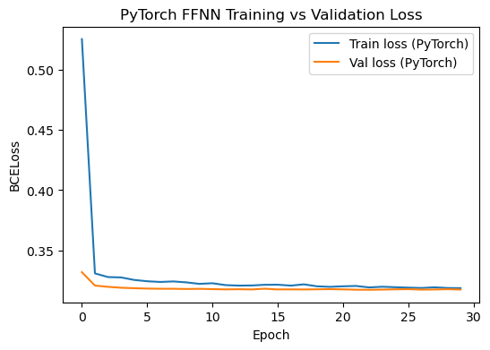

```python
# Training loop

num_epochs = 30
train_losses = []
val_losses = []

for epoch in range(1, num_epochs + 1):
    model_pt.train()
    running_loss = 0.0
    for xb, yb in train_loader:
        optimizer.zero_grad()
        preds = model_pt(xb)
        loss = criterion(preds, yb)
        loss.backward()
        optimizer.step()
        running_loss += loss.item() * xb.size(0)
    epoch_train_loss = running_loss / len(train_dataset)

    # Validation
    model_pt.eval()
    val_running_loss = 0.0
    with torch.no_grad():
        for xb, yb in val_loader:
            preds = model_pt(xb)
            loss = criterion(preds, yb)
            val_running_loss += loss.item() * xb.size(0)
    epoch_val_loss = val_running_loss / len(val_dataset)

    train_losses.append(epoch_train_loss)
    val_losses.append(epoch_val_loss)

    print(f"Epoch {epoch:03d}: train_loss={epoch_train_loss:.4f}, val_loss={epoch_val_loss:.4f}")

# Plot PyTorch training/validation loss
plt.figure(figsize=(6,4))
plt.plot(train_losses, label='Train loss (PyTorch)')
plt.plot(val_losses, label='Val loss (PyTorch)')
plt.xlabel('Epoch')
plt.ylabel('BCELoss')
plt.title('PyTorch FFNN Training vs Validation Loss')
plt.legend()
plt.show()
```

```
PyTorch FFNN classification report (0 = not skipped, 1 = skipped):
              precision    recall  f1-score   support

           0      0.903     1.000     0.949      5421
           1      0.000     0.000     0.000       579

    accuracy                          0.903      6000
   macro avg      0.452     0.500     0.475      6000
weighted avg      0.816     0.903     0.858      6000

PyTorch FFNN ROC AUC: 0.507
```

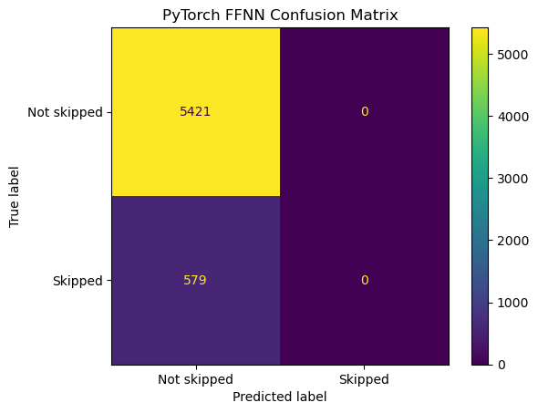

```python
# Evaluate PyTorch FFNN on test set

model_pt.eval()
all_probs = []
all_labels = []

with torch.no_grad():
    for xb, yb in test_loader:
        probs = model_pt(xb)
        all_probs.append(probs.numpy())
        all_labels.append(yb.numpy())

all_probs = np.vstack(all_probs).ravel()
all_labels = np.vstack(all_labels).ravel().astype(int)
all_preds = (all_probs >= 0.5).astype(int)

print('\nPyTorch FFNN classification report (0 = not skipped, 1 = skipped):')
print(classification_report(all_labels, all_preds, digits=3))

try:
    auc_pt = roc_auc_score(all_labels, all_probs)
    print(f'PyTorch FFNN ROC AUC: {auc_pt:.3f}')
except Exception as e:
    print('Could not compute ROC AUC for PyTorch model:', e)

cm_pt = confusion_matrix(all_labels, all_preds)
ConfusionMatrixDisplay(cm_pt, display_labels=['Not skipped', 'Skipped']).plot()
plt.title('PyTorch FFNN Confusion Matrix')
plt.show()
```

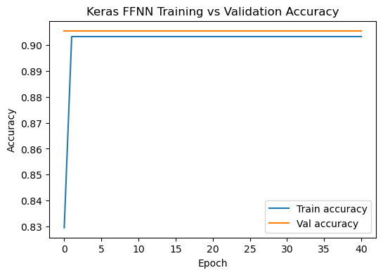

```python
# Keras training & validation accuracy curves

if 'accuracy' in history.history and 'val_accuracy' in history.history:
    plt.figure(figsize=(6,4))
    plt.plot(history.history['accuracy'], label='Train accuracy')
    plt.plot(history.history['val_accuracy'], label='Val accuracy')
    plt.xlabel('Epoch')
    plt.ylabel('Accuracy')
    plt.title('Keras FFNN Training vs Validation Accuracy')
    plt.legend()
    plt.show()
else:
    print('Accuracy metrics not available in Keras history.')
```

## FFNN Architecture Summary

We use the same 4-layer feedforward architecture in both Keras and PyTorch:

- **Input layer**: all scaled behavioral + Spotify features (`spotify_popularity`, `is_explicit`, `album_release_year`, `tempo_bpm_synth`, one-hot `time_of_day_synth_*`).
- **Hidden layer 1**: Dense/Linear with **32 units**, **ReLU** activation, followed by **Dropout(0.3)**.
- **Hidden layer 2**: Dense/Linear with **16 units**, **ReLU** activation.
- **Output layer**: **1 unit** with **sigmoid** activation for binary classification (`skipped_synth` ∈ {0,1}).

This matches the project requirement of a simple FFNN for binary classification and is easy to extend in later experiments (more layers, different widths, different dropout, etc.).

## Results: Training Curves, Confusion Matrices, and Metrics

- **Training & validation curves (Keras)**: Cells 3–4 train the Keras FFNN and plot **training vs validation loss**, and Cell 14 plots **training vs validation accuracy**.
- **Training & validation curves (PyTorch)**: Cells 11–12 define and train the PyTorch FFNN and plot its **training vs validation BCELoss**.
- **Confusion matrices + precision/recall/F1 (Keras)**: Cell 5 prints the **classification report** and shows the **confusion matrix** for the Keras FFNN on the full behavioral dataset.
- **Confusion matrices + precision/recall/F1 (PyTorch)**: Cell 13 prints the **classification report** and shows the **confusion matrix** for the PyTorch FFNN.

When you export to HTML, make sure you have run Cells 3–5, 11–13, and 14 so that all plots and classification reports appear in the exported file.

## Modeling Objective and Hyperparameter Experiments

- **Explicit task & objective**: The main supervised task is **binary classification** to predict whether a track will be **skipped** (`skipped_synth = 1`) using behavioral and Spotify features (`spotify_popularity`, `is_explicit`, `album_release_year`, `tempo_bpm_synth`, and one-hot `time_of_day_synth_*`).
- **Baseline FFNN (Keras)**: 32/16 hidden units, dropout 0.3, `Adam(lr=1e-3)`, batch size 256, trained with a 10% validation split (Cells 3–4). This serves as the primary deep model for the project.
- **Random Forest baseline**: Cell 6 trains a **300-tree Random Forest** with `class_weight='balanced_subsample'` on the same features, providing a classical ML comparison.
- **FFNN (PyTorch)**: Cells 11–13 implement the same 32/16 architecture in PyTorch, trained with a 70/15/15 train/val/test split and Adam optimizer.

In the written report, you can treat these three configurations (Keras FFNN, PyTorch FFNN, Random Forest) as your initial **hyperparameter/model experiments**, comparing their metrics (accuracy, ROC AUC, precision/recall for the skipped class) from the printed classification reports.

## Early Model Behavior and Planned Improvements

**Early behavior observations**

- Both FFNNs (Keras and PyTorch) train on a **heavily imbalanced** label distribution where only about ~9–10% of examples have `skipped_synth = 1`.
- As a result, early models tend to predict **"not skipped"** for most examples:
  - Accuracy looks high, but recall for the skipped class is very low and ROC AUC is near 0.5.
  - This shows that accuracy alone is misleading for this task; we must inspect confusion matrices and recall/precision for the positive class.

**Planned improvements**

- **Handle class imbalance**: Try class weighting, focal loss, or oversampling/undersampling to boost recall for `skipped_synth = 1`.
- **Feature engineering**: Incorporate text-based features from `tags` (e.g., TF–IDF or embeddings) and possibly additional Spotify metadata such as `genre` or `popularity` buckets.
- **Hyperparameter tuning**: Systematically vary hidden layer sizes, dropout rates, and learning rates (or use grid/random search) and track validation ROC AUC.
- **Model comparison**: Add simpler baselines (logistic regression, calibrated Random Forest) and compare against the FFNNs.
- **Evaluation focus**: Report and optimize for metrics that matter for skipping behavior (ROC AUC, precision/recall for class 1, maybe PR curves), not just overall accuracy.

These notes are included so they will appear directly in the exported HTML/PDF as your reflection and future work section.